Skip to main content

# Positive polynomial CLF via SOS

We start with an example in which we show it can happen that even if the hybrid (switched) system is stable, there is no common quadratic Lyapunov function.

**Example 1 (No common quadratic Lyapunov function can be found)** We consider a switched system with two modes, linear models that are parameterized by the matrices $\mathbf A_1$ and $\mathbf A_2$:

```julia
A₁ = [-0.1 -1; 2 -0.1]
A₂ = [-0.1 -2; 1 -0.1]
```

The switching curve is given by $x_1=0$, that is, the vertical axis. The state portrait is in Fig. 1.

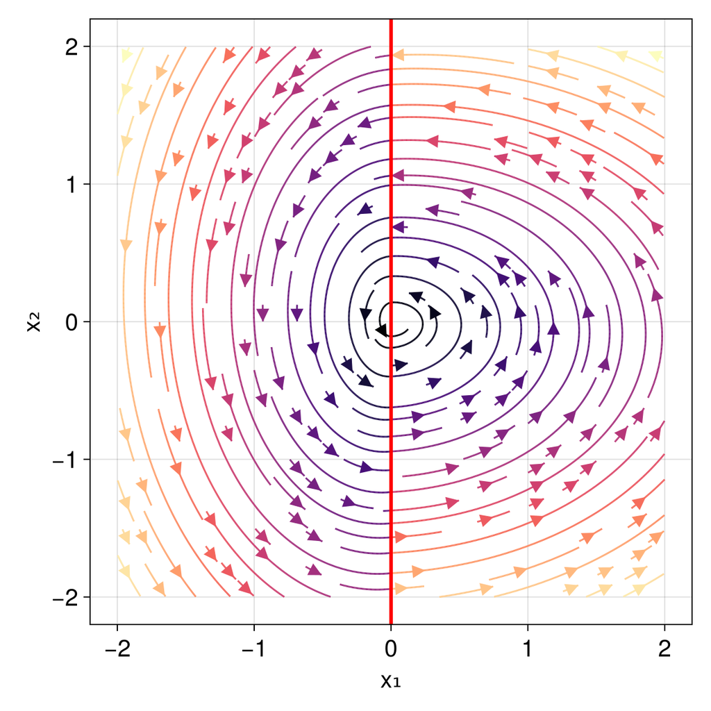

Figure 1: State portrait for the switched system with no common quadratic Lyapunov function

```julia
f₁(x) = A₁*x
f₂(x) = A₂*x
f(x) = x[1] <= 0.0 ? f₁(x) : f₂(x)

using CairoMakie
fig = Figure(size = (600, 600),fontsize=20)
ax = Axis(fig[1, 1], xlabel = "x₁", ylabel = "x₂")
streamplot!(ax,(x₁,x₂)->Point2f(f([x₁,x₂])), -2.0..2.0, -2.0..2.0, colormap = :magma)
vlines!(ax,0.0,ymin=-2.0,ymax=2.0, color = :red, linewidth=3)
fig
```

The equilibrium (the origin) of this switched system appears stable.

The individual systems are stable, which we can immediately see by computing the eigenvalues of the matrices $\mathbf A_1$ and $\mathbf A_2$:

```julia
using LinearAlgebra
eigvals(A₁), eigvals(A₂)
```

```
(ComplexF64[-0.1 - 1.4142135623730951im, -0.1 + 1.4142135623730951im], ComplexF64[-0.1 - 1.4142135623730951im, -0.1 + 1.4142135623730951im])
```

We now search for a common quadratic Lyapunov function for both subsystems. We will formulate this search as an LMI feasibility problem.

```julia
using Convex, SCS, LinearAlgebra
X = Semidefinite(2)
constraint₁ = A₁'*X + X*A₁ ⪯ -I(2)
constraint₂ = A₂'*X + X*A₂ ⪯ -I(2)
constraints = [constraint₁, constraint₂]
problem = satisfy(constraints)
solve!(problem,SCS.Optimizer,silent=true)
```

```
Problem statistics
  problem is DCP         : true
  number of variables    : 1 (4 scalar elements)
  number of constraints  : 3 (12 scalar elements)
  number of coefficients : 24
  number of atoms        : 10

Solution summary
  termination status : INFEASIBLE
  primal status      : INFEASIBLE_POINT
  dual status        : INFEASIBILITY_CERTIFICATE

Expression graph
  satisfy
   └─ nothing
  subject to
   ├─ PSD constraint (convex)
   │  └─ + (affine; real)
   │     ├─ 2×2 Matrix{Int64}
   │     └─ Convex.NegateAtom (affine; real)
   │        └─ …
   ├─ PSD constraint (convex)
   │  └─ + (affine; real)
   │     ├─ 2×2 Matrix{Int64}
   │     └─ Convex.NegateAtom (affine; real)
   │        └─ …
   ├─ PSD constraint (convex)
   │  └─ 2×2 real variable (id: 882…484)
   ⋮
```

The solver does not find a solution. We are now inclined to conclude that there is no common quadratic Lyapunov function for both subsystems. You may wonder if trying another solver or two could make our conclusion more robust ([Mosek](https://www.mosek.com/products/mosek/) solver interfaced from Julia via MosekTools.jl is a recommendable alternative), but we can also try to solve the dual problem to have full trust in the conclusion.

**NoteDual LMI problem confirms the infeasibility of the primal one**

It is possible to certify infeasibility of the primal optimization problem by certifying feasibility of the dual one. Namely, if there are matrices $\bm R_1\succeq 0$ and $\bm R_2\succeq 0$ such that the following matrix is positive semidefinite
$$\bm R_1\mathbf A_1^\top+\mathbf A_1\bm R_1 + \bm R_2\mathbf A_2^\top+\mathbf A_2\bm R_2 \succeq 0,$$
and not all the three matrices zero, then the primal problem is infeasible (see [1, Sec. 2.2.1]).

```julia
R₁ = Semidefinite(2)
R₂ = Semidefinite(2)
R₀ = A₁*R₁ + R₁*A₁' + A₂*R₂ + R₂*A₂'
constraints = [R₀ ⪰ 0, tr(R₀) + tr(R₁) + tr(R₂) == 1]   # normalization excludes R₀ = R₁ = R₂ = 0
dual_problem = satisfy(constraints)
solve!(dual_problem, SCS.Optimizer, silent=true)
dual_problem.status
```

```
OPTIMAL::TerminationStatusCode = 1
```

The conclusion about the imposibility to find a single quadratic Lyapunov function common for both subsystems is also supported by plotting the invariant sets for the two subsystems. First, we need to compute respective Lyapunov functions for the two subsystems.

```julia
X₁ = Semidefinite(2)
constraint₁ = A₁'*X₁ + X₁*A₁ ⪯ -I(2)
problem₁ = satisfy(constraint₁)
solve!(problem₁,SCS.Optimizer,silent=true)
X₁.value
```

```
2×2 Matrix{Float64}:
 154.948     4.54339
   4.54338  77.5695
```

```julia
X₂ = Semidefinite(2)
constraint₂ = A₂'*X₂ + X₂*A₂ ⪯ -I(2)
problem₂ = satisfy(constraint₂)
solve!(problem₂,SCS.Optimizer,silent=true)
X₂.value
```

```
2×2 Matrix{Float64}:
 77.5695    -4.54339
 -4.54338  154.948
```

Recall now the important property of a Lyapunov function that its sublevel set $\{\bm x \mid V(\bm x) \leq \alpha\}$ is *forward (also positive) invariant*. We plot invariant sets corresponding to some particular values of $\alpha$ for both subsystems superposed on the state portrait in Fig. 2.

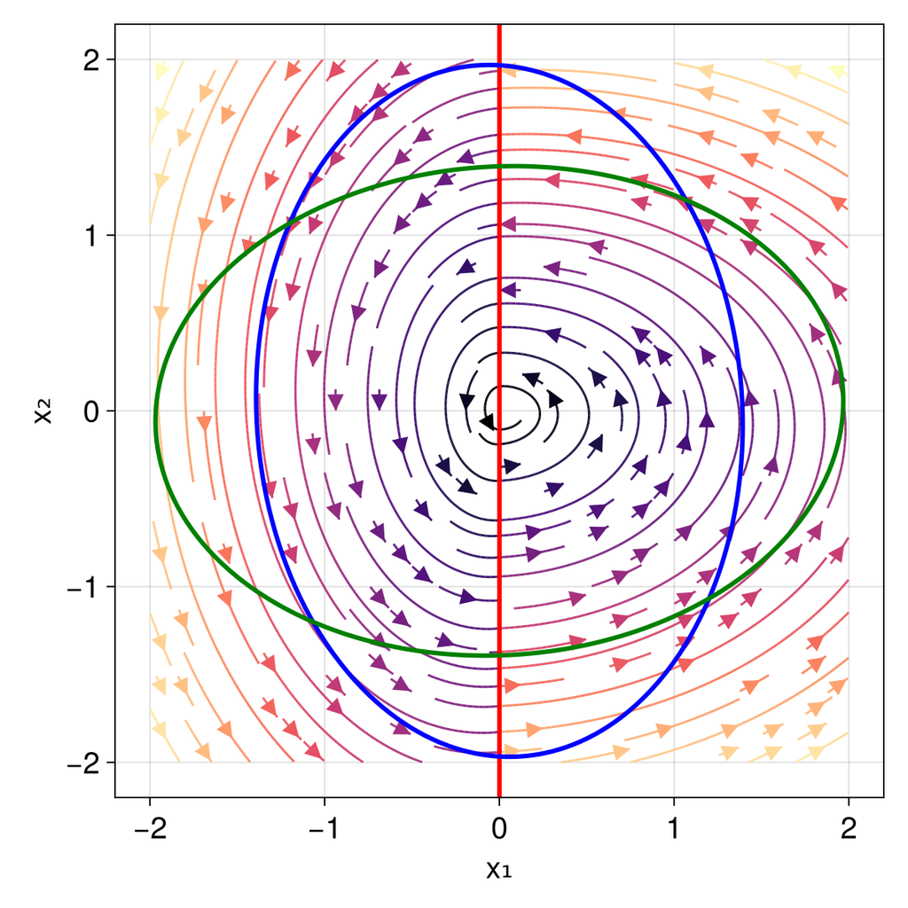

Figure 2: Invariant ellipses for the two subsystems superposed on the state portrait

```julia
x1s = LinRange(-2, 2, 100)
x2s = LinRange(-2, 2, 100)
V₁(x) = x'*X₁.value*x
V₂(x) = x'*X₂.value*x
V1s = [V₁([x₁,x₂]) for x₁ in x1s, x₂ in x2s]
V2s = [V₂([x₁,x₂]) for x₁ in x1s, x₂ in x2s]
contour!(x1s, x2s, V1s, levels=[300.0], linewidth=3, color=:blue)
contour!(x1s, x2s, V2s, levels=[300.0], linewidth=3, color=:green)
fig
```

We can see in Fig. 2 that none of the two ellipses works as an invariant set for the switched system – a state trajectory entering the set leaves it afterwards. No way to to come up with a single ellipse (hence a single quadratic Lyapunov function) that would work here.

## Quadratic LF is just a multivariate quadratic polynomial

So far we considered quadratic Lyapunov functions – and it may be useful to display their prescription explicitly in the scalar form
$$\begin{aligned}
V(\bm x) &= \bm x^\top \bm P \bm x\\
&= \begin{bmatrix}x_1 & x_2\end{bmatrix} \begin{bmatrix} p_{11} & p_{12}\\ p_{12} & p_{22}\end{bmatrix} \begin{bmatrix}x_1\\ x_2\end{bmatrix}\\
&= p_{11}x_1^2 + 2p_{12}x_1x_2 + p_{22}x_2
\end{aligned}$$
to show that, indeed, a quadratic Lyapunov function is a (multivariate) quadratic polynomial.

Now, if quadratic polynomials are not enough, it is natural to consider polynomials of a higher degree. The crucial question is, however: how do we enforce positive definiteness?

## Positive/nonnegative polynomials

The question that we ask is this: is the polynomial $p(\bm x), \; \bm x\in \mathbb R^n$, positive (or at least nonnegative) on the whole $\mathbb R^n$? That is, we ask if
$$p(\bm x) > 0,\quad (\text{or}\quad p(\bm x) \geq 0)\; \forall \bm x\in\mathbb R^n.$$

**Example 2** Consider the polynomial $p(\bm x)= 2x_1^4 + 2x_1^3x_2 - x_1^2x_2^2 + 5x_2^4$. Is it nonnegative for all $x_1\in\mathbb R, x_2\in\mathbb R$?

Additionally, $\bm x$ can be restricted to some $\mathcal X\sub \mathbb R^n$ and we ask if
$$p(\bm x) \geq 0 \;\forall\; \bm x\in \mathcal X.$$

Once we started working with polynomials, *semialgebraic sets* $\mathcal X$ are often considered, asthese are defined by polynomial inequalities such as
$$g_j(\bm x) \geq 0, \; j=1,\ldots, m.$$

But this we are only going to need in the next chapter, when we consider *Multiple Lyapunov Functions* (MLF) approach to stability analysis.

### How can we check positivity/nonnegativity of polynomials?

Gridding is certainly not the way to go – we need conditions on the coefficients of the polynomial so that we can do some optimization later.

**Example 3** Consider a univariate polynomial
$$p(x) = x^4 - 4x^3 + 13x^2 - 18x + 17.$$
Does it hold that $p(x)\geq 0 \; \forall x\in \mathbb R$? Without plotting (hence gridding) we can hardly say. But what if we learn that the polynomial can be written as
$$p = (x-1)^2 + (x^2 - 2x + 4)^2$$

Obviously, whatever the two squared polynomials are, after squaring they become nonnegative. And summing nonnegative numbers yields a nonnegative result. Let’s generalize this.

## Sum of squares (SOS) polynomials

If we can express the polynomial as a *sum of squares* (SOS) of some other polynomials, the original polynomial is nonnegative, that is,
$$\boxed{p(\bm x) = \sum_{i=1}^k p_i(\bm x)^2\; \Rightarrow \; p(\bm x) \geq 0,\; \forall \bm x\in \mathbb R^n.}$$

The converse does not hold in general – not every nonnegative polynomial is SOS! There are only three cases, for which SOS is a necessary and sufficient condition of nonnegativeness:

- $n=1$: univariate polynomials. The degree (the highest power) $d$ can be arbitrarily high (but even, obviously),
- $d = 2$ and $n$ is arbitrary: multivariate polynomials of degree two (note that for $p(\bm x) = x_1^2 + x_1x_2^2$ the degree $d=3$).
- $n=2$ and $d = 4$: bivariate polynomials of degree 4 (at maximum).

For all other cases all we can say is that
$$p(\bm x)\, \text{is}\, \mathrm{SOS} \Rightarrow p(\bm x)\geq 0\, \forall \bm x\in \mathbb R^n.$$

**Note**

Hilbert conjectured in 1900 in the 17th problem that every nonnegative polynomial can be written as a sum of squares of rational functions. This was later proved correct. It turns out, that this fact is not as useful as the SOS using polynomials because of impossibility to state apriori the bounds on the degrees of the polynomials defining those rational functions.

## How to get an SOS representation of a polynomial (or prove that none exist)?

### Univariate case

Back to the univariate example first. And we do it through an example.

**Example 4** We consider the polynomial in the Example 3. One of the two squared polynomials is $x^2 - 2x + 4$. We can write it as
$$x^2 - 2x + 4 = \underbrace{\begin{bmatrix}4 & -2 & 1\end{bmatrix}}_{\bm v^\top} \underbrace{\begin{bmatrix} 1 \\ x \\ x^2\end{bmatrix}}_{\bm z}.$$

Then the squared polynomial can be written as
$$(x^2 - 2x + 4)^2 = \bm z^\top \bm v \bm v^\top \bm z.$$

Note that the the product $\bm v \bm v^\top$ is a positive semidefinite matrix of rank one.

We can similarly express the second squared polynomial
$$x-1 = \underbrace{\begin{bmatrix} -1 & 1 & 0\end{bmatrix}}_{\bm v^\top} \underbrace{\begin{bmatrix} 1 \\ x \\ x^2\end{bmatrix}}_{\bm z}$$
and then
$$(x - 1)^2 = \bm z^\top \begin{bmatrix} -1 \\ 1 \\ 0\end{bmatrix} \begin{bmatrix} -1 & 1 & 0\end{bmatrix} \bm z.$$

Summing the two squares we get the original polynomial. But while doing this, we can sum the two rank-one matrices.
$$\begin{aligned}
p(x) &= x^4 - 4x^3 + 13x^2 - 18x + 17\\
&= \begin{bmatrix} 1 & x & x^2\end{bmatrix} \bm P \begin{bmatrix} 1 \\ x \\ x^2\end{bmatrix}
\end{aligned},$$
where $\bm P\succeq 0$ is
$$\bm P = \underbrace{\begin{bmatrix} 4 \\ -2 \\ 1\end{bmatrix} \begin{bmatrix} 4 & -2 & 1\end{bmatrix}}_{\bm P_1} + \underbrace{\begin{bmatrix} -1 \\ 1 \\ 0\end{bmatrix} \begin{bmatrix} -1 & 1 & 0\end{bmatrix}}_{\bm P_2}$$

The matrix that defines the quadratic form is positive semidefinite and of rank 2. Indeed, the rank of the matrix is given by the number of squared terms in the SOS decomposition.

### Multivariate case

In a general multivariate case we can proceed similarly. Just form the vector $\bm z$ from all possible monomials:
$$\bm z = \begin{bmatrix}1 \\ x_1 \\ x_2 \\ \\ \vdots \\ x_n\\ x_1^2 \\ x_1 x_2 \\ \vdots \\ x_n^2\\\vdots \\x_1x_2\ldots x_n^{2}\\ \vdots \\ x_n^d \end{bmatrix}$$

But how to determine the coefficients of the matrix? We again show it by means of an example.

We consider the polynomial $p(x_1,x_2)=2x_1^4 +2x_1^3x_2 − x_1^2x_2^2 +5x_2^4$. We define the vector $\bm z$ as
$$\bm z = \begin{bmatrix} x_1^2 \\ x_1x_2 \\ x_2^2\end{bmatrix}.$$

Note that we could also write it fully as
$$\bm z = \begin{bmatrix} 1 \\ x_1\\ x_2\\ x_1^2 \\ x_1x_2 \\ x_2^2\end{bmatrix},$$
but we can see that the first three terms are not going to be needed. If you still cannot see it, feel free to continue with the full version of $\bm z$, no problem.

Then the polynomial can be written as
$$p(x_1,x_2)=\begin{bmatrix} x_1^2 \\ x_1x_2 \\ x_2^2\end{bmatrix}^\top \begin{bmatrix} p_{11} & p_{12} & p_{13}\\ p_{12} & p_{22} & p_{23}\\p_{13} & p_{23} & p_{33}\end{bmatrix} \begin{bmatrix} x_1^2 \\ x_1x_2 \\ x_2^2\end{bmatrix}.$$

After multiplying the producs out, we get
$$\begin{aligned}
p(x_1,x_2)&={\color{blue}p_{11}}x_1^4 + {\color{blue}p_{33}}x_2^4 \\
&\quad + {\color{blue}2p_{12}}x_1^3x_2 + {\color{blue}2p_{23}}x_1x_2^3\\
&\quad + {\color{blue}(2p_{13} + p_{22})}x_1^2x_2^2
\end{aligned}$$

There are now 5 coefficients in the above polynomial (they are highlighted in blue). Equating them to the particular values gives 5 equations. In our case, the five equations are
$$\begin{aligned}
p_{11} &= 2,\\
2p_{12} &= 2,\\
2p_{13} + p_{22} &= -1,\\
2p_{23} &= 0,\\
p_{33} &= 5.
\end{aligned}$$

But the matrix $\bm P$ is parameterized by 6 coefficients. Hence we need one more equation. The sixth condition is the linear matrix inequality (LMI)

$$\bm P\succeq 0.$$

This can be solved as the feasibility problem with linear equality and semidefinite constraints using the code below.

```julia
using Convex, SCS

p₁₁ = Variable()
p₁₂ = Variable()
p₁₃ = Variable()
p₂₂ = Variable()
p₂₃ = Variable()
p₃₃ = Variable()

P = [p₁₁ p₁₂ p₁₃; p₁₂ p₂₂ p₂₃; p₁₃ p₂₃ p₃₃]

linear_constraints = [
    p₁₁ == 2,
    2p₁₂ == 2,
    2p₁₃ + p₂₂ == -1,
    2p₂₃ == 0,
    p₃₃ == 5
]

semidefinite_constraint = [P ⪰ 0]

constraint = vcat(linear_constraints, semidefinite_constraint)

problem = satisfy(constraint)
solve!(problem, SCS.Optimizer, silent=true)
```

```
Problem statistics
  problem is DCP         : true
  number of variables    : 6 (6 scalar elements)
  number of constraints  : 6 (14 scalar elements)
  number of coefficients : 8
  number of atoms        : 12

Solution summary
  termination status : OPTIMAL
  primal status      : FEASIBLE_POINT
  dual status        : FEASIBLE_POINT

Expression graph
  satisfy
   └─ nothing
  subject to
   ├─ == constraint (affine)
   │  └─ + (affine; real)
   │     ├─ real variable (id: 540…828)
   │     └─ [-2;;]
   ├─ == constraint (affine)
   │  └─ + (affine; real)
   │     ├─ * (affine; real)
   │     │  ├─ …
   │     │  └─ …
   │     └─ [-2;;]
   ├─ == constraint (affine)
   │  └─ + (affine; real)
   │     ├─ * (affine; real)
   │     │  ├─ …
   │     │  └─ …
   │     ├─ real variable (id: 104…260)
   │     └─ [1;;]
   ⋮
```

Apparently, the problem is feasible, hence the polynomial is SOS, hence nonnegative. We can also visualize the polynomial to see that it is indeed nonnegative at least withing some region around the origin.

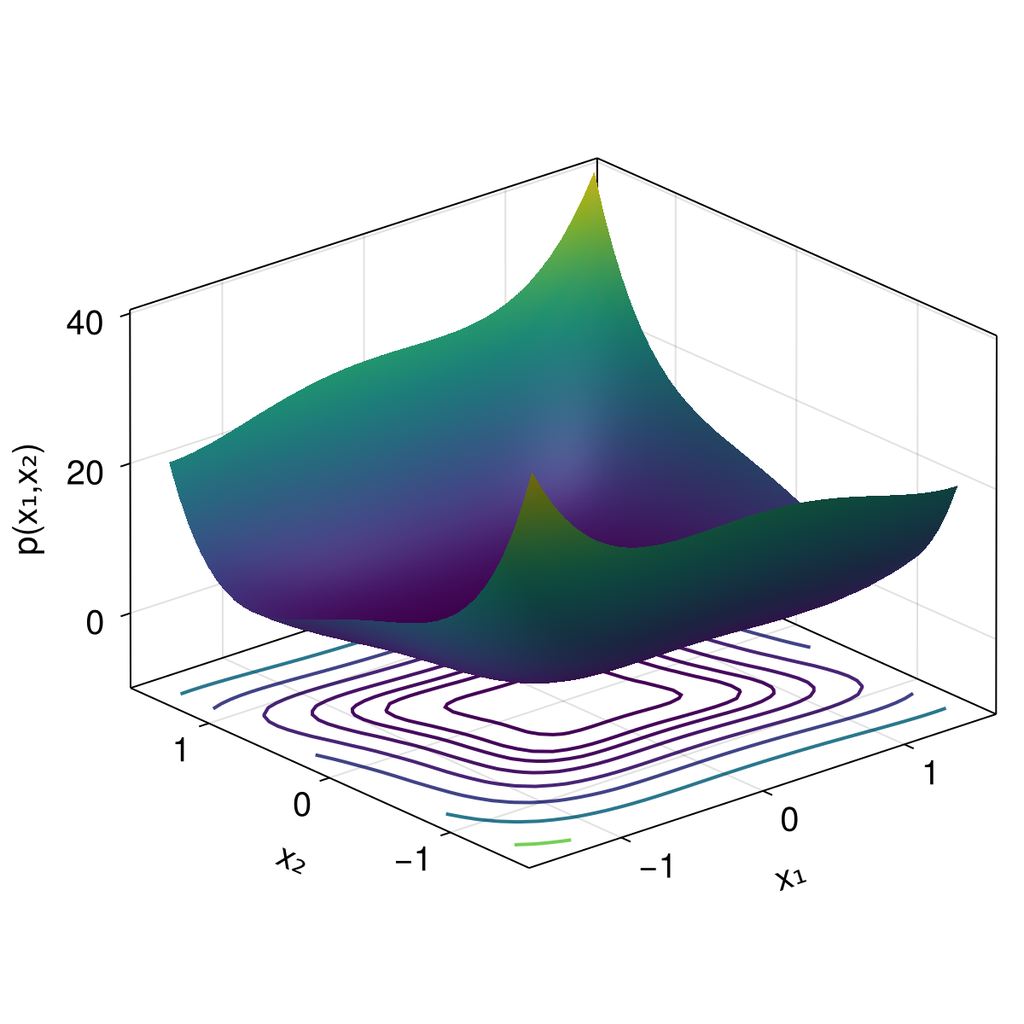

Figure 3: Surface and contour plots of the polynomial $p(x_1,x_2)$ from the example

```julia
p(x1, x2) = 2x1^4 + 2x1^3*x2 - x1^2*x2^2 + 5x2^4

using CairoMakie

X1 = range(-1.5, 1.5, length=40)
X2 = range(-1.5, 1.5, length=40)

Z = [p(x1,x2) for x1 in X1, x2 in X2]

fig = Figure(; size = (600, 600),fontsize=20)
ax = Axis3(fig[1, 1]; xlabel="x₁", ylabel="x₂", zlabel="p(x₁,x₂)", protrusions=(60, 0, 0, 0))
surface!(ax, X1, X2, Z; colormap=:viridis)
zfloor = -10.0                     # Level of the horizontal plane with the contours
cp = contour!(ax, X1, X2, Z; levels=[0.1, 0.5, 1, 2, 4, 8, 16, 32], colormap=:viridis, colorrange=extrema(Z), linewidth=2)
translate!(cp, 0, 0, zfloor)
zlims!(ax, zfloor, maximum(Z))
fig
```

## Searching for an SOS polynomial Lyapunov function

We can now formulate the search for a nonnegative polynomial function $V(\bm x)$ as a search within the set of SOS polynomials of a prescribed (even) degree $d$.

However, for a Lyapunov function, we need positiveness (actually positive definiteness), not just nonnegativeness. Therefore, instead of $V(\bm x) \; \text{is SOS}$, we are going to impose the condition
$$\boxed{
V(\bm x) - \phi(\bm x) \; \text{is SOS},}$$
where $\phi(\bm x) = \epsilon \sum_{i=1}^n x_i^{d}$ for some (typically very small) $\epsilon > 0$. This is pretty much the same trick that we used in the LMI formulation when we needed enforce strict inequalities.

What remains to complete the conditions for Lyapunov stability, is to express the requirement that the time derivative of $V(\bm x)$ is nonpositive. This can also be done by requiring that *minus* the time derivative of the polynomial Lyapunov function, which is a polynomial too, is SOS too.

$$\boxed
{-\nabla V(\bm x)^\top \mathbf f(\bm x)\; \text{is SOS}.}$$

If asymptotic stability is required instead of just Lyapunov one, the condition is that the time derivative is strictly negative, that is, we can require that
$$\boxed
{-\nabla V(\bm x)^\top \mathbf f(\bm x) - \phi(\bm x)\; \text{is SOS}.}$$

## Searching for a SOS polynomial common Lyapunov function

Back to hybrid systems. For Lyapunov stability, the problem is to find $V(\bm x)$ such that

$$\boxed{
\begin{aligned}
V(\bm x) - \phi(\bm x) \; &\text{is SOS},\\
-\nabla V(\bm x)^\top \mathbf f_1(\bm x)\; &\text{is SOS},\\
-\nabla V(\bm x)^\top \mathbf f_2(\bm x)\; &\text{is SOS},\\
\vdots\\
-\nabla V(\bm x)^\top \mathbf f_r(\bm x)\; &\text{is SOS},
\end{aligned}
}$$
while for asymptotic stability, the conditions are
$$\boxed{
\begin{aligned}
V(\bm x) - \phi(\bm x) \; &\text{is SOS},\\
-\nabla V(\bm x)^\top \mathbf f_1(\bm x) - \phi(\bm x)\; &\text{is SOS},\\
-\nabla V(\bm x)^\top \mathbf f_2(\bm x) - \phi(\bm x)\; &\text{is SOS},\\
\vdots\\
-\nabla V(\bm x)^\top \mathbf f_r(\bm x) - \phi(\bm x)\; &\text{is SOS}.
\end{aligned}
}$$

**Example 5** We now search for an SOS polynomial common Lyapunov function for a system with arbitrary switching, for which no common quadratic Lyapunov function could be found. We use SumOfSquares.jl package to formulate the problem within the JuMP framework (this still requires choosing a suitable solver).

```julia
A₁ = [-5 -4; -1 -2];
A₂ = [-2 -4; 20 -2];

using DynamicPolynomials
using SemialgebraicSets
using SumOfSquares
using MosekTools
using CSDP        # Alternative solver, if Mosek solver is not available.

solver = optimizer_with_attributes(Mosek.Optimizer, MOI.Silent() => true)
model = SOSModel(solver)
@polyvar x[1:2]

d = 8
@variable(model, V, SumOfSquares.Poly(monomials(x,d)))

using LinearAlgebra # Needed for `dot`
dV1dt = dot(differentiate(V, x), A₁*x)
dV2dt = dot(differentiate(V, x), A₂*x)

ϵ = 1e-3
φ = x[1]^d + x[2]^d

@constraint(model, V >= ϵ*φ)
@constraint(model, dV1dt <= -ϵ*φ)
@constraint(model, dV2dt <= -ϵ*φ)

JuMP.optimize!(model)

JuMP.is_solved_and_feasible(model)
```

```
true
```

```julia
L = value(V)
```

```
0.004253860568051705x₂⁸ - 0.006153867654831888x₁x₂⁷ + 0.04500810231852841x₁²x₂⁶ + 0.023371193134535857x₁³x₂⁵ + 0.12589455273613273x₁⁴x₂⁴ + 0.14507380502294745x₁⁵x₂³ + 0.29673618524082906x₁⁶x₂² + 0.16592003821663812x₁⁷x₂ + 0.278361845691958x₁⁸
```

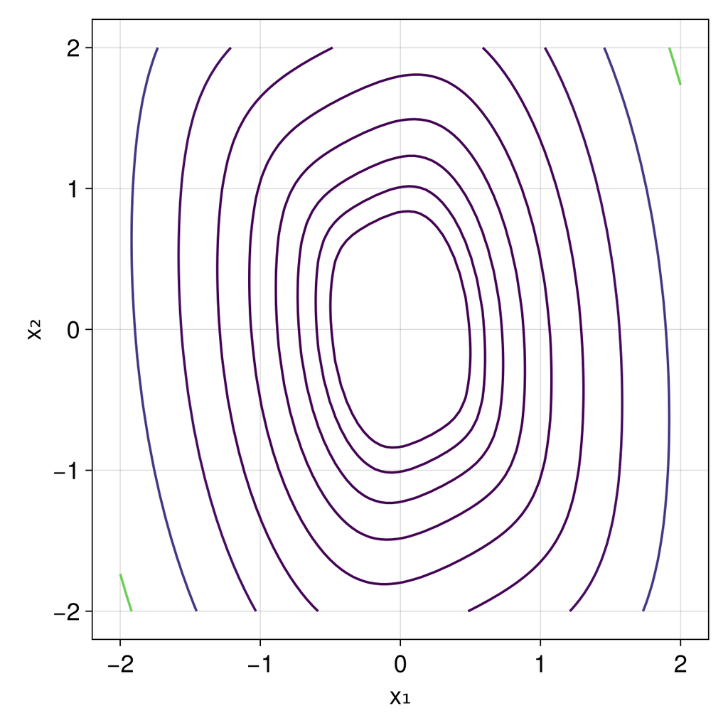

Figure 4: Contour plot of the SOS polynomial Lyapunov function

```julia
x₁ = x₂ = range(-2.0, 2.0; length=100)
X₁ = [i for i in x₁, j in x₂]
X₂ = [j for i in x₁, j in x₂]

Z1 = [L([X₁[i,j], X₂[i,j]]) for i in 1:length(x₁), j in 1:length(x₂)]

levels = logrange(1e-3,1e3,10)

using CairoMakie
fig = Figure(size = (600, 600),fontsize=20)
ax = Axis(fig[1, 1], xlabel = "x₁", ylabel = "x₂")
contour!(ax, x₁, x₂, Z1; levels=levels, linewidth=2)
fig
```

Back to top

## References

[1]

S. Boyd, L. El Ghaoui, E. Feron, and V. Balakrishnan, *Linear Matrix Inequalities in System and Control Theory*. in Studies in Applied and Numerical Mathematics. Society for Industrial and Applied Mathematics, 1994. Accessed: Apr. 16, 2021. [Online]. Available: https://web.stanford.edu/~boyd/lmibook/